# A4: Incarceration

by Yuzhi Fan

### Introduction

In recent decades, the issue of racial disparities in the U.S. criminal justice system has garnered significant attention. One of the most striking manifestations of this problem is the disproportionate incarceration rates among different racial groups, particularly between black and white individuals. This analysis aims to delve into these disparities by examining incarceration data, with a focus on understanding the extent and trends of racial disproportionality in prison and jail populations over time. By calculating and analyzing specific variables such as the proportion of black and white individuals in prisons and jails, we seek to uncover patterns and provide insights into the systemic issues contributing to these disparities. This exploration is crucial for informing policy decisions and advancing efforts toward a more equitable criminal justice system.

### Summary Information

I calculated the proportion of black and white people in prison to be **0.4644114**, and **0.3706276** respectively. Also, I calculated the proportion of black and white people in jail to be **0.3864186**, and **0.431639** respectively. Considering that white people comprise of approximately 2/3 of the entire US population, and black people is only about 10%, the proportion listed above is disproportionately high for black people, which indicates the present-day racism in policing behaviors and judicial systems. Furthermore, I calculated the max ratio of black people in jail occurred in **1970** with a ratio of **0.6589776**, and the min occurred in **2016** with a ratio of **0.4018064**. It shows that the racism situation is getting better over the years.

### The Dataset

The incarceration data utilized in this analysis was compiled by the Vera Institute, a prominent nonprofit organization dedicated to criminal justice reform and research. The data collection process likely involved a combination of methods such as surveys, administrative records, and collaborations with various criminal justice agencies across the United States. The primary aim of this data collection effort was to comprehensively examine trends, disparities, and systemic issues within the U.S. criminal justice system, particularly concerning incarceration rates and their intersection with demographic factors such as race and socioeconomic status. With likely numerous observations representing diverse geographic regions, demographic profiles, and temporal snapshots, the dataset offers a rich source of information for understanding the complexities of incarceration in the United States. However, ethical considerations loom large in the analysis of such data. Questions regarding potential biases in data collection methods, power dynamics within the criminal justice system, and the ethical implications of research findings on affected communities must be carefully navigated. Furthermore, limitations such as sampling biases, incomplete data, and contextual factors affecting incarceration rates underscore the importance of critical scrutiny and cautious interpretation when working with this dataset.

### Trends Over Time Chart

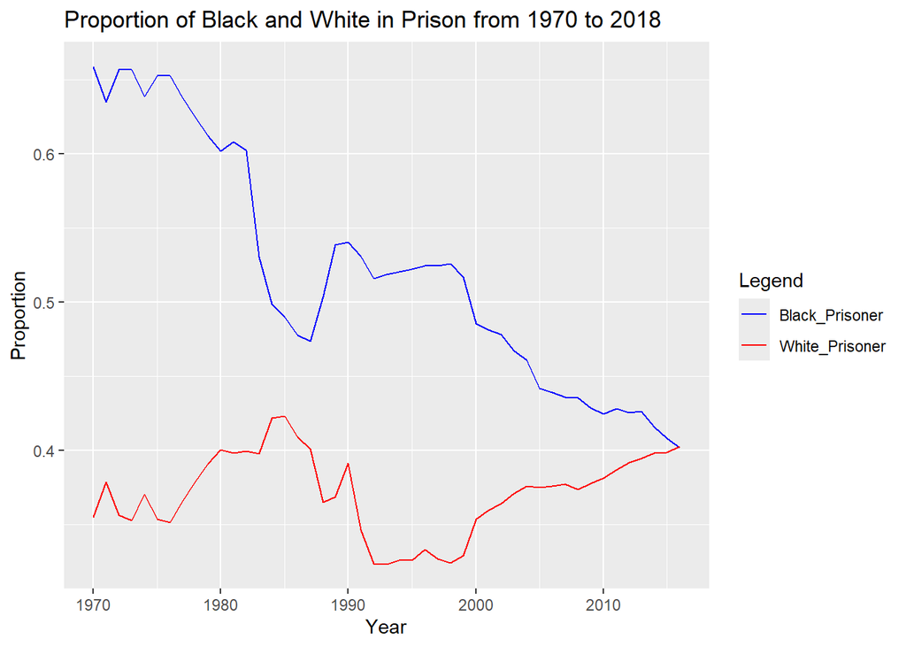

### Variable Comparison Chart

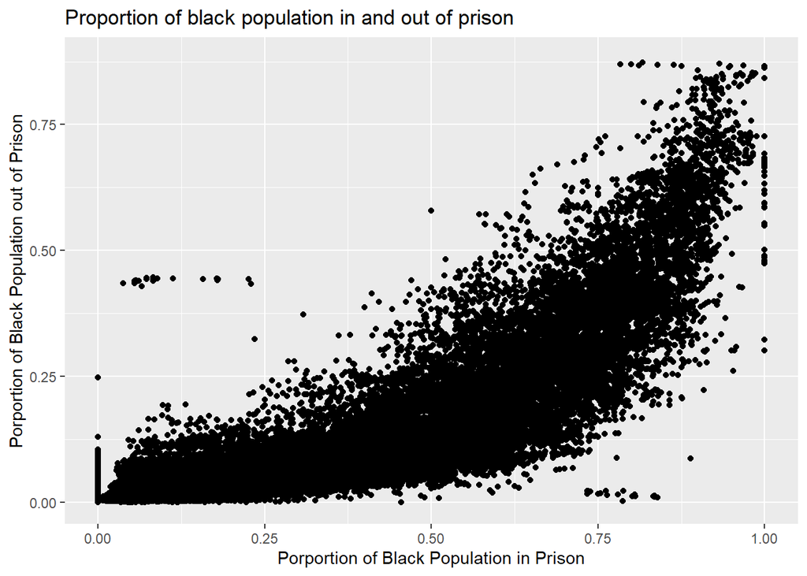

This chart have shown the correlation of black population proportion in prison and in society. It have shown a positive and strong relationship between the two variables. Also, there is a lot of datapoints on lower right half of the graph, indicating datapoints of prisons who have higher black prisoner proportion than the population proportion of the society. It reveals the racial injustice faced by black people, as their population proportion in prison is frequently higher than their population proportion in a region.

### Map

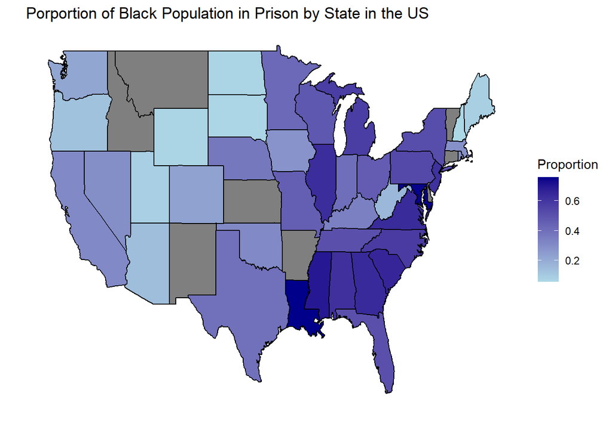

This map have shown the proportion of black population in prison across different state in the US. The map clearly shows that the black population proportion in southeast part of the US is significantly higher than other states. This could mean that there is especially severe discrimination and racism against the black, or black population is higher than other regions as a whole.